# Introduksjon

## Don’t worry, be happy!

```r
library(tidyverse) #used for general data manipulation
library(rvest) #used for webscraping
library(rgdal) #read the shape file
### world happiness index scores 2022 ###

## webscrape data
link <-  "https://countryeconomy.com/demography/world-happiness-index" #website url
page <-  read_html(link)

country <-  page %>% html_nodes("td:nth-child(1)") %>% html_text() #scrapes the country column

happiness_score <-  page %>% html_nodes(".numero+ .numero") %>% html_text() #scrapes the WHI score column

whi <-  data.frame(country, happiness_score, stringAsFactors = FALSE) #combines the scraped columns into a new dataframe
## clean dataframe
whi$country_sub <- str_sub(
  whi$country,
  start = 1, end = -5
) #removes [+] symbol from country names

whi <- whi %>%
  select(country_sub, happiness_score) %>% #removes stringASFactors and country columns
  rename(country = country_sub) #renames country_sub back to country

whi$happiness_score <- as.numeric(whi$happiness_score) #convert score from character to integer
arrange(whi,desc(happiness_score))
```

```
                   country happiness_score
1                  Finland           7.821
2                  Denmark           7.636
3                  Iceland           7.557
4              Switzerland           7.512
5              Netherlands           7.415
6               Luxembourg           7.404
7                   Sweden           7.384
8                   Norway           7.365
9                   Israel           7.364
10             New Zealand           7.200
11                 Austria           7.163
12               Australia           7.162
13                 Ireland           7.041
14                 Germany           7.034
```

[output cut: 130 more lines]

## Høy økonomisk levestandard (målt ved BNP)

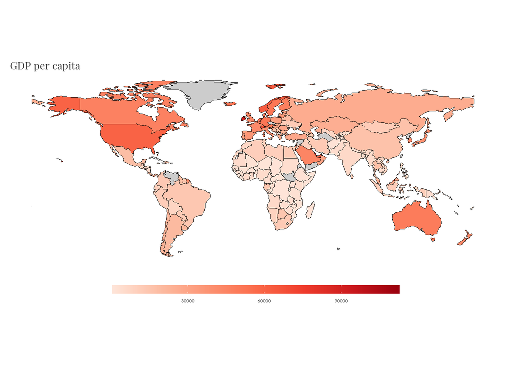

```r
library(owidR)
gdp<-owid("gdp-per-capita-worldbank")
owid_map(gdp)
```

## Høy levestandard (målt ved forventet levetid)

```r
library(owidR)
#owid_search("life expectancy")
life<-owid("life-expectancy")
owid_map(life,mode = "view", palette = "Blues")
```

[interactive chart not shown]

## Minst forskjeller mellom folk (målt ved Gini-indeks)

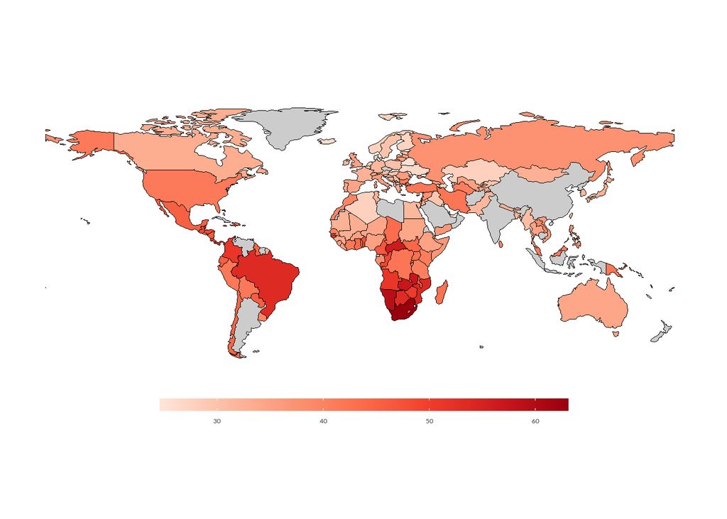

```r
library(owidR)
#inequality
#owid_search("Gini Index")
#Let's download Gini index dataset
gini<-owid("economic-inequality-gini-index")
#Draw a map
owid_map(gini)
```

## Personlig frihet (Human Freedom Index 2016)

```r
library(openintro)
hfi_2016 <- hfi %>%
  filter(year == 2016) %>%
  select(countries, hf_score)
hfi_2016$hf_score <- as.numeric(hfi_2016$hf_score) #convert score from character to integer
hfi_rank<-arrange(hfi_2016,desc(hf_score),30)
hfi_rank<-as.data.frame(hfi_rank)
hfi_rank
```

```
                 countries hf_score
1              New Zealand 8.887410
2              Switzerland 8.787759
3                Hong Kong 8.776840
4                Australia 8.582219
5                   Canada 8.565863
6              Netherlands 8.554421
7                  Denmark 8.547820
8                  Ireland 8.504565
9           United Kingdom 8.497918
10                 Finland 8.472184
11                  Norway 8.471241
12                  Taiwan 8.465697
13                 Germany 8.462596
14                 Estonia 8.436851
```

[output cut: 148 more lines]

## Den nordiske modellen

- Hvorfor er Norge blant landene med gladest og friest befolkning, høyest levestandard og minst forskjeller mellom folk?
- Og hvorfor er det slik at Norge har vært blant de flinkeste til å absorbere økonomiske sjokk og andre eksternt påførte kriser?
- Mye av forklaringen på suksesshistorien ligger i hvordan vi har organisert den norske samfunnsmodellen
  - hvordan vi har bygd opp institusjoner og utviklet mekanismer for koordinering mellom politikkområder og institusjoner

## Men…

#### **Innføringskurs i mikroøkonomi**

- Inngrep på markedet fører til redusert velferd
- Konklusjon:
  - Det er best å la markedene være i fred.
  - Unngå alle inngrep på markedene.

#### **Den nordiske modellen**

- Veldig mange og veldig store inngrep på markedene
  - spesielt på arbeidsmarkedet, utdanningsmarkedet og helsemarkedet

## Hva er kjernen i den nordiske modellen?

1. Den norske modellen er samspillet mellom det organiserte arbeidslivet, brede offentlige velferdsordninger og den økonomiske politikken
2. Modellen innebærer at staten og arbeidslivets parter samarbeider sentralt for å håndtere interessemotsetninger og finne løsninger på viktige samfunnsutfordringer
3. Modellen innebærer også samarbeid og håndtering av interessemotsetninger på den enkelte arbeidsplass

## Grunnpillarene i den tradisjonelle nordiske modellen

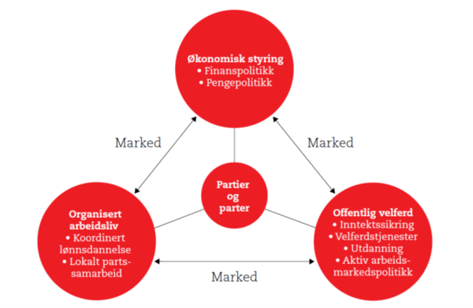

## Mål, midler og verdier

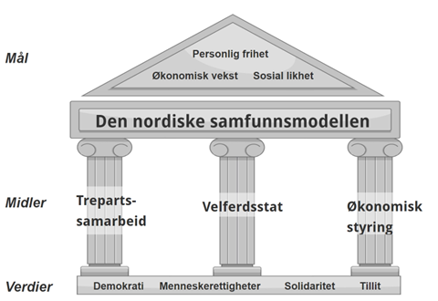

## Tillit (Eurostat)

```r
#Trust
library(eurostat)
dat <- get_eurostat(id="ilc_pw03")
```

```
Reading cache file C:\Users\mia100\AppData\Local\Temp\RtmpaUfdAd/eurostat/ilc_pw03_date_code_FF.rds
```

```
Table  ilc_pw03  read from cache file:  C:\Users\mia100\AppData\Local\Temp\RtmpaUfdAd/eurostat/ilc_pw03_date_code_FF.rds
```

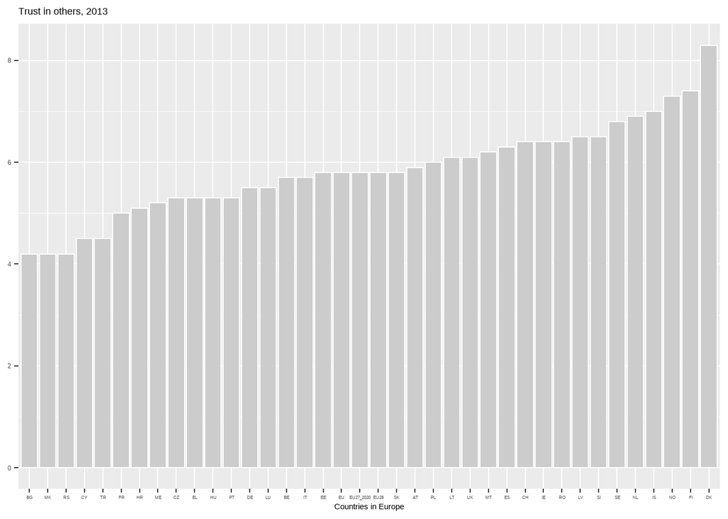

```r
dat_2013 <- dat %>%
  filter(time == "2013-01-01"& sex=="T"& age=="Y_GE16"& isced11=="TOTAL" &indic_wb=="OTHTST")
ggplot(dat_2013, aes(x = reorder(geo, values), y =values))+
  geom_col(color = "white", fill = "grey80") +
  theme(axis.text.x = element_text(size = 6)) +
  labs(title = "Trust in others, 2013",
       y = NULL, x = "Countries in Europe")
```

## Ulike typer velferdssater

- Den anglosaksiske (USA, Canada, Australia, UK)
  - Liberal modell
  - Minimumsvelferdstater som skal sikre mot fattigdom
  - Ytelsene lave og behovsprøvd
  - Få universelle ordninger
- Den nordiske
  - Mindre vekt på marked og familie
  - Universell, sikre sosial trygghet, stor grad av omfordeling og forsikring
- En tysk vei
  - sosialstaten - den Bismarckske modell
  - Obligatoriske sosialforsikringer av mannen i arbeid, subsidiær sikring av familiemedlemmer
  - Husholdsbasert omsorg
  - Stabilitet og statusforskjeller
- En latinsk vei
  - ‘familiarisme’
  - Den fascistiske arv: sterk stat på helse, stor rolle for familien (=kvinner), god inntektssikring av ‘kjerneproletariatet’

## Hva har modellen bidratt til?

- Høy levestandard
- Høy sysselsetting
- Stabil arbeidstilknytning
- Koordinering og avtaler
- Høy avtaledekning
- Lønnsulikhet
- Ulikhet i formue
- Lite utenforskap
- Politiske endringer
- Tillit

[figure not shown]

## Høy sysselsetting

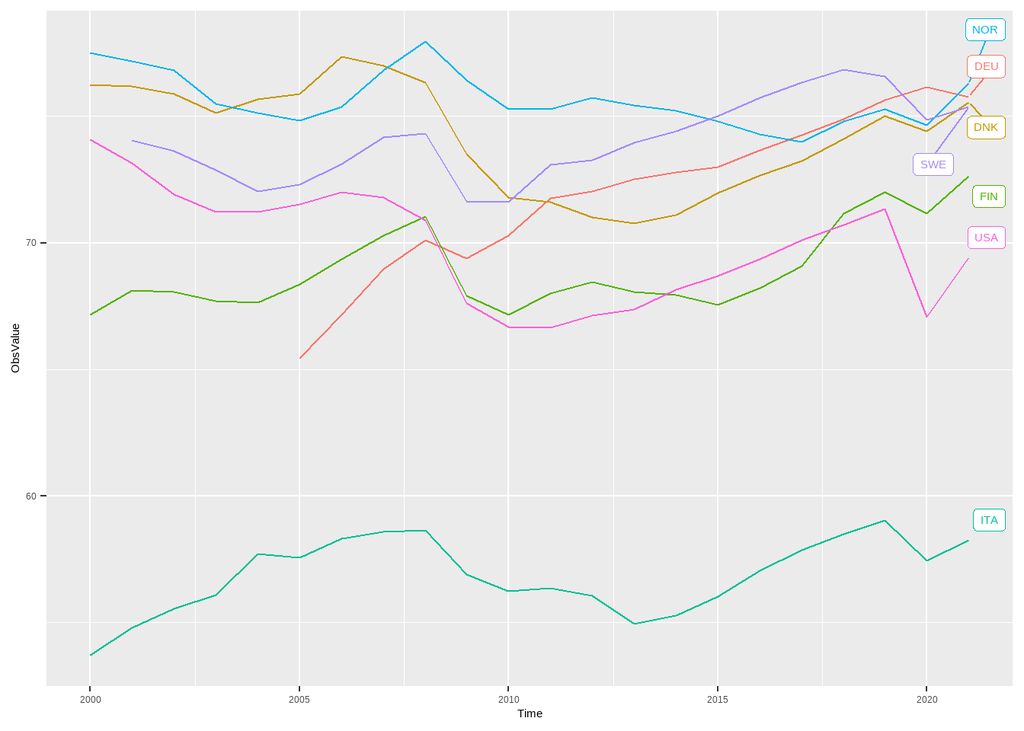

```r
library(OECD)
employment <- get_dataset("STLABOUR",
                  filter = "DNK+FIN+DEU+ITA+NOR+SWE+USA.LREM64TT.STSA.A",
                  pre_formatted = TRUE)
library(tidyverse)
library(ggrepel)
employment%>%
  mutate(label = if_else(Time == max(Time), as.character(LOCATION), NA_character_)) %>%
  mutate(ObsValue = as.numeric(ObsValue))%>%
  mutate(Time = as.numeric(Time))%>%
  filter(Time>1999)%>%
ggplot(aes(x=Time, y=ObsValue,colour =LOCATION, group = LOCATION))+
  geom_line()+
  geom_label_repel(aes(label = label),
                   nudge_x = 1,
                   na.rm = TRUE)+
  theme(legend.position="none")
```

## Liten lønnsulikhet

S80/S20 viser forholdet mellom samlet inntekt for de 20 prosent rikeste og de 20 prosent fattigste i befolkningen

```r
library(eurostat)
library(knitr)
library(tidyverse)
library(janitor)
library(ggcharts)
library(ggflags)
library(rvest)
library(countrycode)
library(magrittr)
library(ggrepel)
ineq <- get_eurostat(id = "ilc_di11",
                     type = "label")
```

```
Reading cache file C:\Users\mia100\AppData\Local\Temp\RtmpaUfdAd/eurostat/ilc_di11_date_label_FF.rds
```

```
Table  ilc_di11  read from cache file:  C:\Users\mia100\AppData\Local\Temp\RtmpaUfdAd/eurostat/ilc_di11_date_label_FF.rds
```

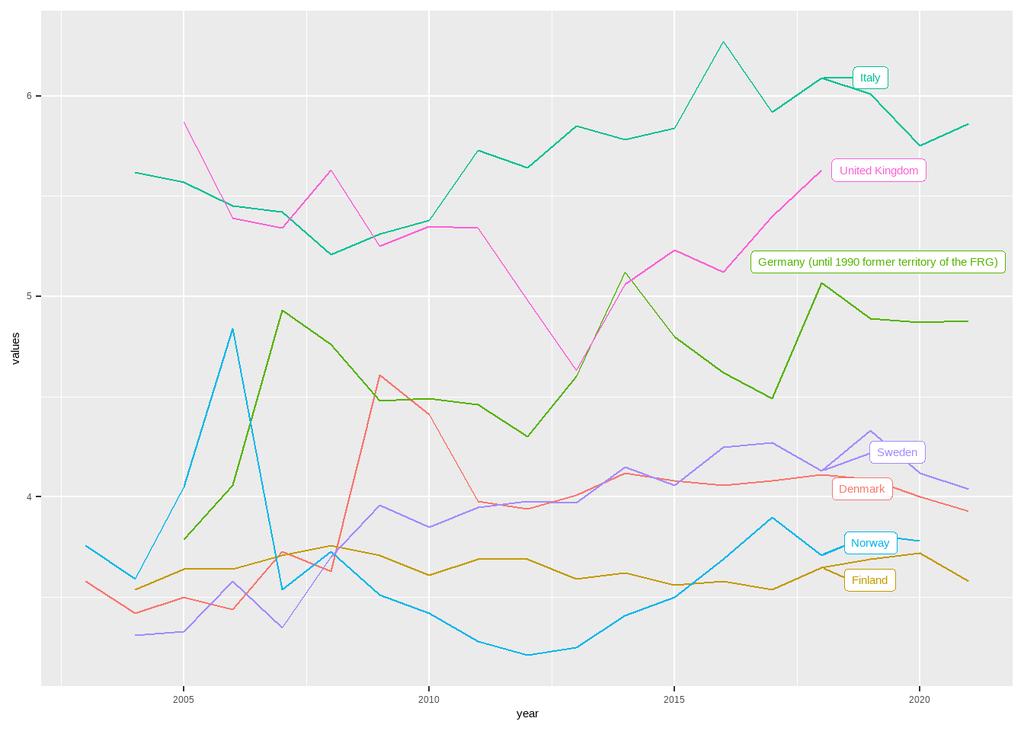

```r
#Some quick data cleaning. First changing the date to a numeric variable.
ineq$year <- as.numeric(format(ineq$time, format = "%Y"))
ineq$sex<-as.factor(ineq$sex)
ineq$age<-as.factor(ineq$age)

countries<-c("Finland","Denmark", "Norway","Sweden", "Germany (until 1990 former territory of the FRG)", "United Kingdom", "Italy")
ineq %>%
  filter(sex == "Total"&age=="Total") %>%
  filter(geo %in%countries) %>%
  select(geo, values, year) -> ineq_series

ineq_series%>%
  mutate(label = if_else(year == 2018, as.character(geo), NA_character_)) %>%
  ggplot(aes(x=year, y=values,colour =geo, group = geo))+
  geom_line()+
  geom_label_repel(aes(label = label),
                   nudge_x = 1,
                   na.rm = TRUE)+
  theme(legend.position="")
```

## Utfordringer

- Demografiske endringer
  - befolkningen øker
  - levealderen øker
  - andelen yrkesaktive antas å synke
  - andelen innvandrere forventes æ øke
- Fallende sysselsetting
- Fallende organisasjonsgrad
- Teknologiske endringer og nye kompetansekrav
- Økende ulikhet
- Klimaendringer

## Læringsmål: Kunnskaper og forståelse

- **Studentene skal ha innsikt i sentrale trekk ved den nordiske samfunnsmodellen**
- **Studentene skal forstå offentlige inngrep i økonomien og ha innblikk i velferdsøkonomiske problemstillinger**
  - **skal forstå teoretiske argumenter bak velferdsordningenes innretning og omfang**
  - **skal forstå insentivproblemer som oppstår i skjæringspunktet mellom velferdsstat og marked**
    - Bakgrunnen til, og ulike politiske og moralfilosofiske begrunnelser for, velferdsstaten
    - Hvordan effektivitet, rettferdighet og insentivproblemer påvirker arbeidsmarkedet og ulike velferdspolitiske ordninger
    - Hvordan ulikhet defineres og operasjonaliseres i normative analyser
    - Beskatningens samfunnsøkonomiske kostnader og begrensninger
    - Hvordan arbeidsmarkedet fungerer, blant annet trekantssamarbeidets rolle i lønnsdannelsen, og hvordan familie-, innvandrings- og likestillingspolitikken påvirker sysselsetting og verdiskaping
    - Teoretiske argumenter bak viktige overføringsordninger i folketrygden og disinsentiveffekter knyttet til disse
    - Offentlig sektor sin rolle i utdannelses- og helsesektoren

## Læringsmål: Ferdigheter

- Kunne inkorporere politiske og moralfilosofiske teorier i analyse av velferdsstaten
- Kunne analysere
  - hvordan en effektiv allokering av ressursene kan oppnåes i imperfekte markeder
  - fattigdom, ulikhet og velferd
  - Analysere ulike overføringsordninger opp mot effektivitet, fordeling og insentiveffekter
- Kunne analysere og drøfte relasjonen mellom forsikringsmarkeder og sosialforsikringssystem
- Kunne anvende offentlig tilgjengelig statistikk for å analysere aktuelle problemstillinger innen faget

## Læringsmål: Kompetanse

- Ha innsikt om relevante problemstillinger relatert til velferdsstaten
- Kunne planlegge og gjennomføre arbeidsoppgaver og benytte både økonomisk teori og empiriske data for å analysere problemstillinger knyttet til velferdsstaten i tråd med etiske krav og retningslinjer.
- Kunne formidle sentrale teorier, problemstillinger og løsninger i grafisk, analytisk og muntlig form.
- Være i stand til å delta i samfunnsdebatten om velferdspolitikkens ulike virkemidler og deres bærekraft.